# Exercise 3

1. Now that you have seen how to fit a curve with given data, your task now is to create the data from the `Fibonnaci` problem, using the recursive and the linear method. For each of those methods you are going to fit the time that the function takes to perform in function of the size `n`. Try with first with these functions (for the recursive and the linear independently):
   - Linear
   - Polynomial ( degree up to 10)
   - Exponential

   Are the errors increasing or not? what do you think is the bet fit for each of those method and why?
2. Now to test how good your fit was compute $R^2$, since `Scipy` does not provide that, so we must calculate it. To do so we remember its definition $$ R^2=1-\frac{\text{Variance of residuals}}{\text{Total variance}} $$

   where $\text{Variance of residuals}=\text{Var}(\hat{y}-y)$ (with $\hat{y}$, the fit of that curve) and $\text{Total variance}=\text{Var}(y)$. Implement your own function that computes the variance of an array and then compute the $R^2$ for each fit. What is the best according to the result of $R^2$?
3. In order to know how well our model is (the fitting we did) we must show the result of the fit with its respective confidence interval. The confidence interval can be obtained by adding to each parameter it's respective variance or errors. If we only add one time the variance and rest one time the variance we get 3 curves $y(p),y(p-\sigma),y(p+\sigma)$ this form what is call the confidence interval of $1-\sigma$, these intervals are very used in many fields to rely in a model. if the $5-\sigma$ interval is small we can trust more this model. Your task here is to compute a $3-\sigma$ confidence interval and see how big or small it is. to plot this you can use the next lines

   ```
   import matplotlib.pylab as plt
    plt.plot(x, y_fit, 'k-')
    plt.fill_between(x, y_minus, y_plus)
    plt.show()
   ```

# Fitting Gaussians

Now, let's look at a more challenging example - least squares fitting over multiple independent dimensions. Why is this challenging? The curve fitting algorithm we're using here only accepts `1D` arrays and expects the fitting function to only return a `1D` array. But this won't stop us.... First let's define our independent Gaussian function: $$ {\displaystyle f(x,y)={\frac {1}{2\pi \sigma _{X}\sigma _{Y}}}\exp \left(-{\frac {1}{2}}\left[{\frac {(x-\mu _{X})^{2}}{\sigma _{X}^{2}}}+{\frac {(y-\mu _{Y})^{2}}{\sigma _{Y}^{2}}}\right]\right)} $$

```
import numpy as np
def Gausian_2D(x,y,mu_x,mu_y,sigma_x,sigma_y):
    return 1.0/(2*np.pi*sigma_x*sigma_y)*np.exp(-0.5*
                                                ((x-mu_x)**2/sigma_x**2)
                                                - 0.5*
                                                ((y-mu_y)**2/sigma_y**2))

x=np.linspace(-5,5,1000)
y=np.linspace(-8,8,1000)
X,Y=np.meshgrid(x,y)
z=Gausian_2D(X,Y,0,0,1,3)
from mpl_toolkits.mplot3d import Axes3D
import matplotlib.pyplot as plt
fig = plt.figure()
ax = fig.gca(projection='3d')

ax.plot_surface(X, Y, z, cmap=cm.coolwarm,linewidth=0, antialiased=False)

plt.show()
```

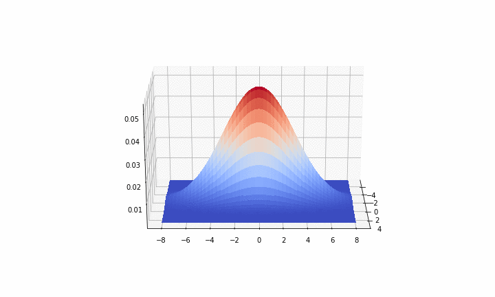

Now your task here is to use the method `curve_fit` from `Scipy` to fit some data generated from this function. To do this you must start doing the following:

1. Use he previous line of code to generate the data from the function `Gaussian_2D` and add to it some random noise (Normal), you are going to test with something called White noise which is basically random numbers generate from a Gaussian distribution with Zero mean and $\sigma$ small. Once you have generated the noise you add it to the values from the function `Gassian_2D`. Then you have to flatten the result and pass to the parameters in the `fit_curve` function. Since `fit_curve` only receives one input as the variable you have to change the function that computes the Gaussian in 2D to receive either the mesh or a tuple of the variables. Also (and this is important) the function must return a 1D array (this is because the way `Scipy` was done) so you may find useful the function [flatten](https://docs.scipy.org/doc/numpy/reference/generated/numpy.ndarray.flatten.html) to do this or if you are a fan of doing the things for yourself try to do it. Finally you will fit the function with the introduced noise.
2. Check how the parameters of the fit are compared to the ones you introduced. Does this make sense or is too far from what you expected?. From time to time is is useful to give some initial conditions and this can be done by passing the parameter `p0` in the `fit_curve`, try to refit your curve by using this parameters. Did it change, how much?
3. Plot the function you obtained and compare it to the one without noise. For this part you may find useful to plot with a [pcolormesh](https://matplotlib.org/3.1.1/gallery/images_contours_and_fields/pcolormesh_levels.html#sphx-glr-gallery-images-contours-and-fields-pcolormesh-levels-py) and use the [contour plot](https://matplotlib.org/3.1.1/gallery/images_contours_and_fields/contour_demo.html#sphx-glr-gallery-images-contours-and-fields-contour-demo-py)